# DS 2006 Final Exam Prep Questions

**Q.** Consider earnings (in thousands of dollars) the first year after graduation from UVA with an undergraduate degree. If X is normal with $\mu = 60$ and $\sigma = 10$, what level of earnings represents the top 90th percentile?

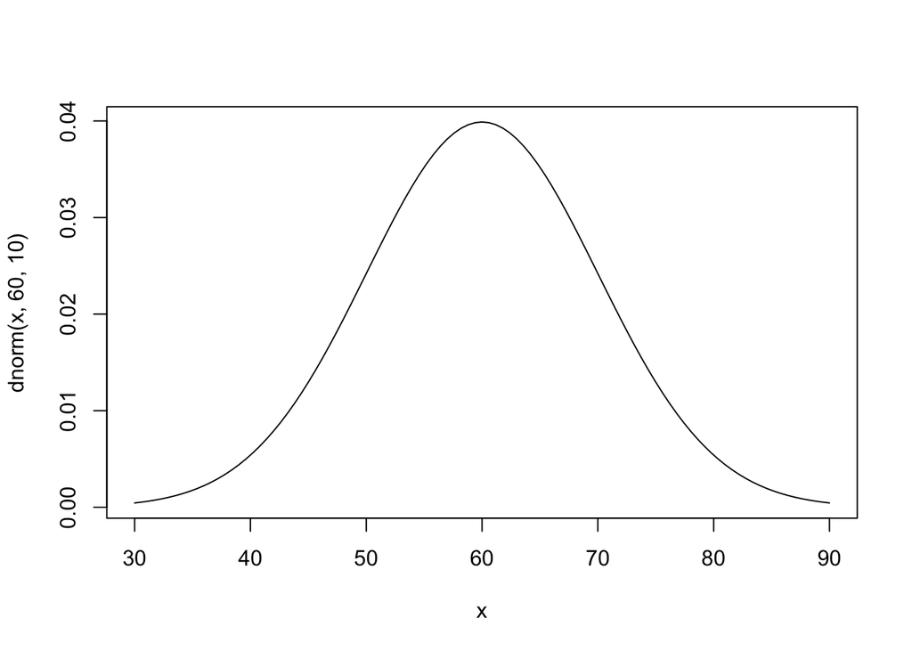

```r
# density function
curve(dnorm(x, 60, 10), 30, 90)
```

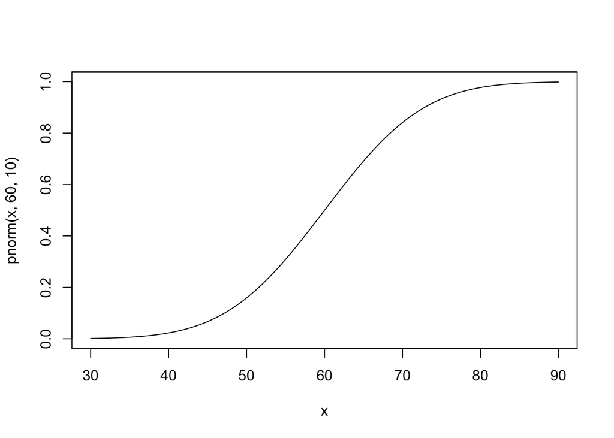

```r
# distribution function
curve(pnorm(x, 60, 10), 30, 90)
```

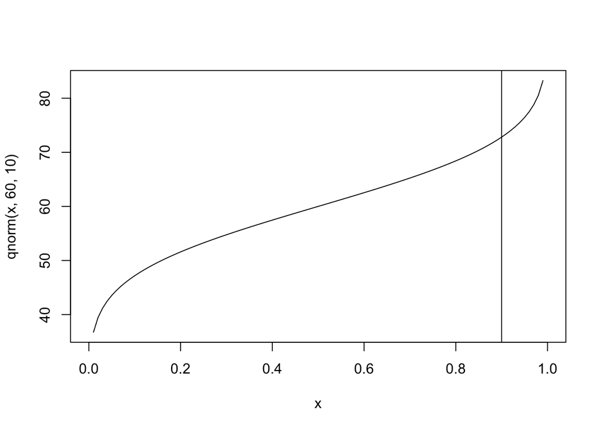

```r
# quantile function visual rep of 90th percentile
curve(qnorm(x, 60, 10), 0, 1)
abline(v=.9)
```

```r
# exact number for 90th percentile
qnorm(.9, 60, 10)
```

```
## [1] 72.81552
```

> explain and implement different approaches for fitting probability models from data (Maximum likelihood, Bayesian posterior)

**Q.** Suppose an upcoming election for UVA student body president is between two candidates. In a survey of 30 students, 20 voiced support for candidate A. Use the Desmos [calculator (link)](https://www.desmos.com/calculator/rayscxmk2t) to fit a probability model with Bayesian methods for the election, specifically the probability that candidate A is the prefered by the student body. Report the 95% credible interval.

first consider the prior - reasonable assumption for 2 candiates would be m = .5 then consider the spread - bring in personal perspective on range of support m2 - higher value indicates student must have support add data to H (support) and T1 (didnt support)

**Q.** Suppose an upcoming election for UVA student body president is between two candidates. In a survey of 30 students, 20 voiced support for candidate A. Use the Desmos [calculator (link)](https://www.desmos.com/calculator/xxxskep7rj) to fit a probability model with Maximum Likelihood for the election, specifically the probability that candidate A is the prefered by the student body. Report the 1/20 support interval.

input data: n is total h is in support change k until it is 0.05 record p and interval

**Q.** When is a Bayesian approach prefered to a maximum likelihood approach?

When we have and are confident in our prior beliefs. However, there is no rule that says our beleifs are correct and unoversal. In a case where there is no consensus, than a max like approach is prefered because it eliminates the diagreement.

> explore how to communicate uncertainty when constructing models and answering research questions (support intervals, credible intervals)

**Q.** Repeat the election analysis performed above with additional data. In a survey of 100 students, 60 students voiced support for candidate A. Compare the interval estimates based on the larger dataset to those generated from the smaller dataset. Comment on which analysis you find more persuasive and explain why.

For Basyean: a smaller interval means less uncertainty, so a smaller interval is preferable. therefore, we prefer the analysis with the larger sample size. “95% chance that the data is between these intervals”

For Max Likeleyhood: no prior knowledge, so we are not talking about credibility. Instead we are examining a support interval (K). “The data support hypotheses values of p between __ and __”. interval still got smaller which indicates less uncertainty.

> propagate uncertainty in simulations, visualize the uncertainty inherent in fitting probability models from data

**Q.** Going back to the election question, suppose that the support for candidate A was known to be $p=0.55$. In an election in which 100 students vote, what is the probability that 51 or more votes will be cast for candidate A?

distinguish between knowing bernouli probability versus estimiating from data pbinom

```r
1 - pbinom(50, 100, 0.55)
```

```
## [1] 0.8172718
```

**Q.** Now suppose the the probability is unknown, and is estimated from data. The following shows the distribution for $P$(Votes>50) when estimated from data using a uniform prior and a survey of 30 students with 20 voicing support for the candidate. Add a line to show the solution when $p$ is known. Comment on the uncertainty when $p$ is estimated from data.

plot values from previous qeustion to compare p being know versus p being unknown

when p is unknown, what was a value is know a distribute becauses there is uncertainity assoicated with what p actually is.

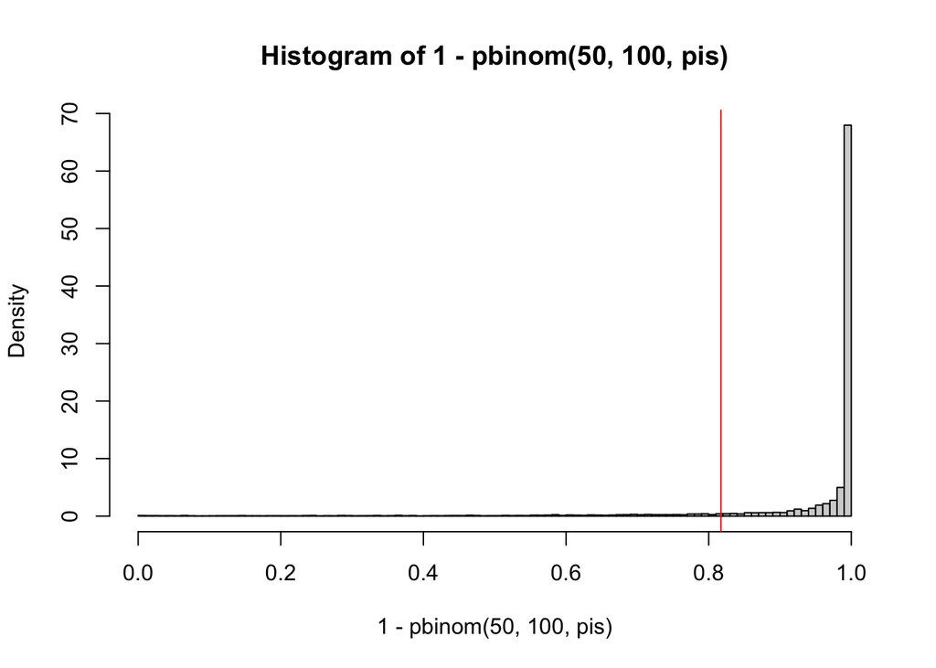

```r
pis <- rbeta(10000, 21, 11)
hist(1-pbinom(50,100,pis), freq=FALSE, breaks=100)
p1 <- 1-pbinom(50, 100, .55)
abline(v = p1, col = "red")
```

> explore the trade-offs of model complexity and generalizability

**Q.** Explain the concept of generalizability in the context of the birthweight data.

how well does our model trasnlate to other studies? what would cause it to not be generalizable? - if data is overfit, than it only fits our observed data but does not relate to the general population.jumps in data are too extreame and use jumps as an example for how data is overfit. relationships in data that do not exist in general population.

> select prior distributions which reflect personal belief (informative vs weakly informative priors)

> implement bayesian updating

> use probability models to build simulations of complex real world processes to answer research questions

**Q:** The Monte Hall problem is a classic game show. Contestants on the show where shown three doors. Behind one randomly selected door was a sportscar; behind the other doors were goats.

At the start of the game, contestants would select a door, say door A. Then, the host would open either door B or C to reveal a goat. At that point in the game, the host would ask the contestant if she would like to change her door selection. Once a contestant decided to stay or change, the host would open the chosen door to reveal the game prize, either a goat or a car.

In this problem, consider a **modified** version of the Monte Hall problem in which the number of doors is **variable**. Rather than 3 doors, consider a game with 4 or 5 or 50 doors. In the modified version of the game, a contestant would select an initial door, say door A. Then, the host would open **one** of the remaining doors to reveal a goat. At that point in the game, the host would ask the contestant if she would like to change her door selection. Once a contestant decided to stay or change, the host would open the chosen door to reveal the game prize, either a goat or a car.

Consider two strategies:

1. Always stay with the first door selected.
2. Always switch to the unopened door.

**A.** The function `game` below plays a single game of Monte Hall. The function returns a vector of length two, the first element is the prize under strategy 1 and the second element is the prize under strategy 2. The function has a single input parameter, N, which is the number of doors in the game.

Use the `game` function to estimate the probability that both strategies *simultaneously* result in a goat. Let **N=4**. (Note the word *simultaneously*. This means that in the same game, both strategies resulted in a goat.)

```r
require(magrittr)
require(dplyr)
# Input N is the number of doors
# spits out the outcome for each of the two stratigies
# we want to know probability of "goat" "goat" for N=4
# replicate the game and

game <- function(N){
  if(N<3) stop("Must have at least 3 doors")
  prize <- sample(c(rep("goat",N-1),"car"), N)
  guess <- sample(1:N,1)
  game <- data.frame(door = 1:N, prize = prize, stringsAsFactors = FALSE) %>%
    mutate(first_guess = case_when(
      door == guess ~ 1
      , TRUE ~ 0
    )) %>%
    mutate(potential_reveal = case_when(
        first_guess == 1 ~ 0
      , prize == "car" ~ 0
      , TRUE ~ 1
    )) %>%
    mutate(reveal = 1*(rank(potential_reveal, ties.method = "random") == 3)) %>%
    mutate(potential_switch = case_when(
      first_guess == 1 ~ 0
      , reveal == 1 ~ 0
      , TRUE ~ 1
    )) %>%
    mutate(switch = 1*(rank(potential_switch, ties.method = "random") == 3))
  c(game$prize[game$first_guess == 1], game$prize[game$switch == 1])
}

# use replicate command to calculate the proportion we want: proportion of 2 in this case is goat goat
r1 <- replicate(1000, sum(game(4) %in% "goat"))
table(r1) |> proportions()
```

```
## r1
##     1     2
## 0.608 0.392
```

```r
r2 <- replicate(1000, game(4) |> paste(collapse = ""))
table(r2) |> proportions()
```

```
## r2
##  cargoat  goatcar goatgoat
##    0.242    0.387    0.371
```